# 03 - Lastne vrednosti in lastni vektorji

Matematično-fizikalni praktikum, oktober 2023  
Luka Skeledžija, 28201079

## Uvod

Enodimenzionalni linearni harmonski oscilator (delec mase $m$ s kinetično energijo $T(p)=p^2/2m$ v kvadratičnem potencialu $V(q)=m\omega^2 q^2/2$) opišemo z brezdimenzijsko Hamiltonovo funkcijo \begin{equation*} H_0 = {1\over 2} \left( p^2 + q^2 \right) \>, \end{equation*} tako da energijo merimo v enotah $\hbar\omega$, gibalne količine v enotah $(\hbar m\omega)^{1/2}$ in dolžine v enotah $(\hbar/m\omega)^{1/2}$. Lastna stanja $|n\rangle$ nemotenega Hamiltonovega operatorja $H_0$ so \begin{equation*} |n\rangle = (2^n n! \sqrt{\pi})^{-1/2} \mathrm{e}^{-q^2/2}\, {\cal H}_n (q)\>, \end{equation*} kjer so ${\cal H}_n$ Hermitovi polinomi. Lastne funkcije zadoščajo stacionarni Schrodingerjevi enačbi \begin{equation*} H_0 | n^0 \rangle = E_n^0 | n^0 \rangle \end{equation*} z nedegeneriranimi lastnimi energijami $E_n^0 = n + 1/2$ za $n=0,1,2,\ldots~$. Matrika $\langle i | H_0 | j\rangle$ z $i,j=0,1,2,\ldots,N-1$ je diagonalna, z vrednostmi $\delta_{ij}(i + 1/2)$ po diagonali. Nemoteni Hamiltonki dodamo anharmonski člen \begin{equation*} H = H_0 + \lambda q^4 \>. \end{equation*} Matriko s tem potencialom v nadaljevanju navajamo s $H$. Tedaj matriko zapišemo kot $$ \begin{equation*} \langle i | H | j \rangle = \langle i | H_0 | j \rangle + \lambda \langle i | q^4 | j \rangle \end{equation*} $$

Za izračun drugega člena si lahko pomagamo z naslednjimi zvezami $$ \begin{align*} &\langle i | q | j \rangle = {1\over 2} \sqrt{i+j+1}\,\, \delta_{|i-j|,1} \\ &\langle i|q^2|j\rangle = {1\over 2} \biggl[ {\sqrt{j(j-1)}} \, \delta_{i,j-2} + {(2j+1)} \, \delta_{i,j} + {\sqrt{(j+1)(j+2)}} \, \delta_{i,j+2} \biggr] \\ &\langle i|q^4|j\rangle = {1\over 2^4}\sqrt{2^i \, i!\over 2^{j} \, j! } \, \biggl[ \, \delta_{i,j+4} + 4\left(2j+3\right) \delta_{i,j+2} + 12 \left(2j^2+2j+1\right) \, \delta_{i,j} \\[3pt] &+ 16j \left(2j^2-3j+1\right) \, \delta_{i,j-2} + 16j\left(j^3-6j^2+11j-6\right) \, \delta_{i,j-4} \biggr] \end{align*} $$ Sedaj rešujemo matrični sistem \begin{equation*} H | n \rangle = E_n | n \rangle \>, \end{equation*} katerega bomo reševali v bazi lastnih funkcij harmonskega oscilatorja $| i \rangle$: \begin{equation*} | n \rangle = \sum_{i=0}^N c_i | i \rangle \end{equation*}

Metodo lahko nato prenesemo tudi na drugačne potenciale. V dodatku je analiziran še kvantni harmonski oscilator z dvema minimumoma, katerega $H$ zapišemo kot \begin{equation*} H = {p^2\over 2} - 2q^2 + {q^4\over 10} \>. \end{equation*} Podobno kot prej lahko matriko zapišemo kot \begin{equation*} \langle i | H | j \rangle = \langle i | H_0 | j \rangle - \frac{5}{2} \langle i | q^2 | j \rangle + \frac{1}{10} \langle i | q^4 | j \rangle \end{equation*} Matriko s tem potencialom v nadaljevanju navajamo s $H_2$.

## Naloga

> Z diagonalizacijo poišči nekaj najnižjih lastnih vrednosti in lastnih valovnih funkcij za moteno Hamiltonko $H = H_0 + \lambda q^4$ ob vrednostih parametra $0\le\lambda\le 1$. Za diagonalizacijo pri večjih $N$ uporabi enega ali več numeričnih postopkov, na primer rutine ${\tt tred2}$ in ${\tt tqli}$ iz zbirke Numerical Recipes ali iz kakega drugega vira (npr Python). Vsaj enega izmed postopkov izvedi 'ročno' (sprogramiraj, uporabi izvorno kodo). Preveri, da v limiti $\lambda\to 0$ velja $E_n\to E_n^0$. Razišči, kako so rezultati odvisni od razsežnosti $N$ matrik $H_0$ oziroma $q^4$. Kakšna je konvergenca lastnih vrednosti pri velikih $N$? Namesto da računamo matrične elemente $q_{ij}=\langle i | q | j \rangle$ in perturbacijsko matriko razumemo kot $[ q_{ij} ]^4$, bi lahko računali tudi matrične elemente kvadrata koordinate $ q^{(2)}_{ij} = \langle i | q^2 | j \rangle$ in motnjo razumeli kot kvadrat ustrezne matrike, $\lambda q^4 \to \lambda [ \, q^{(2)}_{ij} \,]^2 \>,$ ali pa bi računali matrične elemente četrte potence koordinate $q^{(4)}_{ij} = \langle i | q^4 | j \rangle$ in kar to matriko razumeli kot motnjo, $\lambda q^4 \to \lambda [ \, q^{(4)}_{ij} \,] \>.$ Kakšne so razlike med naštetimi tremi načini izračuna lastnih vrednosti in funkcij?  
> **Dodatna naloga**: Poišči še nekaj najnižjih lastnih energij in lastnih funkcij za problem v potencialu z dvema minimumoma $H = {p^2\over 2} - 2q^2 + {q^4\over 10} \>$.

## Princip reševanja

Reševanja naloge se lotimo v dveh delih / z dvema ključnima elementoma. Najprej s pomočjo perturbacijske teorije generiramo matrike, ki bodo nastopale v matrični enačbi. Potrebujemo torej generator ustreznih matrik. V drugem delu pa moramo ta sistem še rešiti. Za to bomo potrebovali program, ki zna dane matrike kar se da učinkovito diagonalizirati in tako rešiti matrično enačbo.

Sledijo štiri poglavja:

1. S pomočjo perturbacijska teorije v 1. redu poiščemo in generiramo nekaj skupnih matričnih Hamiltonovih operatorjev velikosti $N$. Analiziramo učinkovitost uporabljenih metod za različne interpretacije motnje in se odločimo za najučinkovitejšo.
2. Primerjamo različne metode numerične diagonalizacije in se odločimo za najučinkovitejšo.
3. Z numerično diagonalizacijo rešimo matrično enačbo in primerjamo rezultate s harmonskim oscilatorjem.
4. Dodatek: Analiziramo še oscilator v potencialu z dvema minimumoma.

## Hamiltonov matrični operator za an-harmonski oscilator

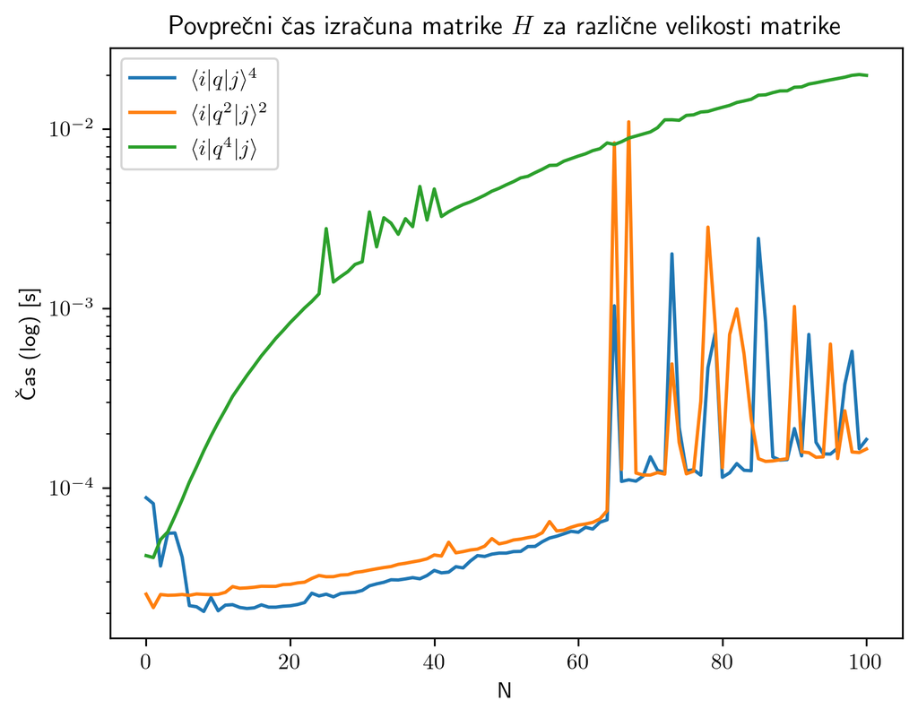

Ugotovimo, da je hitrost izračunavanja največja v prvih dveh primerih, saj uporabljamo knjižnico `numpy`. Za izračun fakultet v zadnjem primeru (zelen graf) uporabljamo dvakrat gnezdeno `for` zanko implementirano v Pythonu. Vendar zadnji princip izračuna ni brez prednosti. Kot opazimo v nadaljevanju, moramo za natančen izračun celotne perturbacijske matrike velikosti $25 \times 25$ v prvih dveh primerih, kjer matrike potenciramo, začeti z matrikami, ki so večje kot $25 \times 25$.

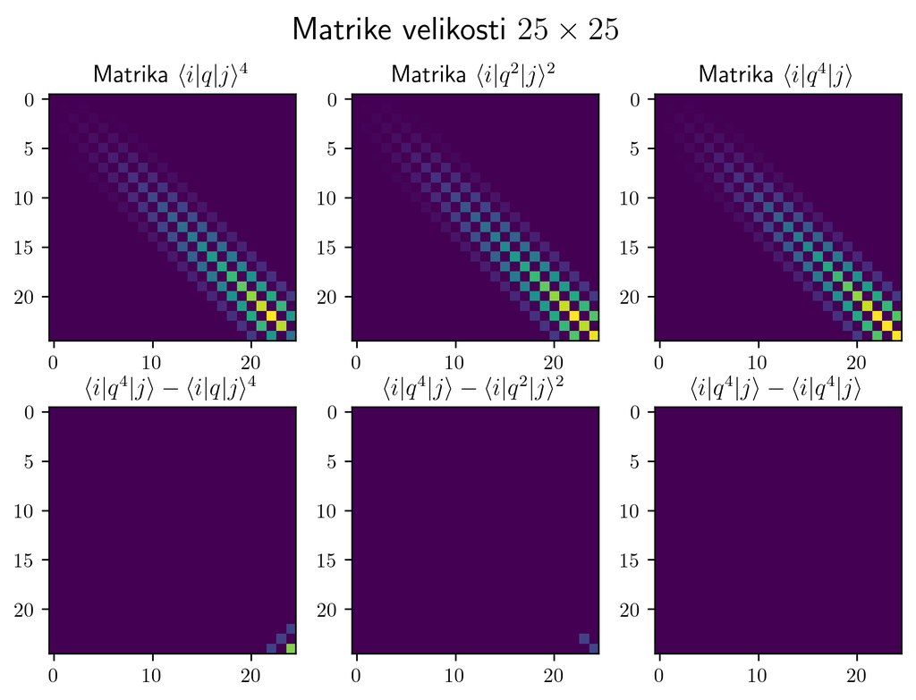

**Primerjava 1:** Vizualizacija in primerjava vrednosti v matrikah (N=25) za različne interpreatacije operatorja potenciala.

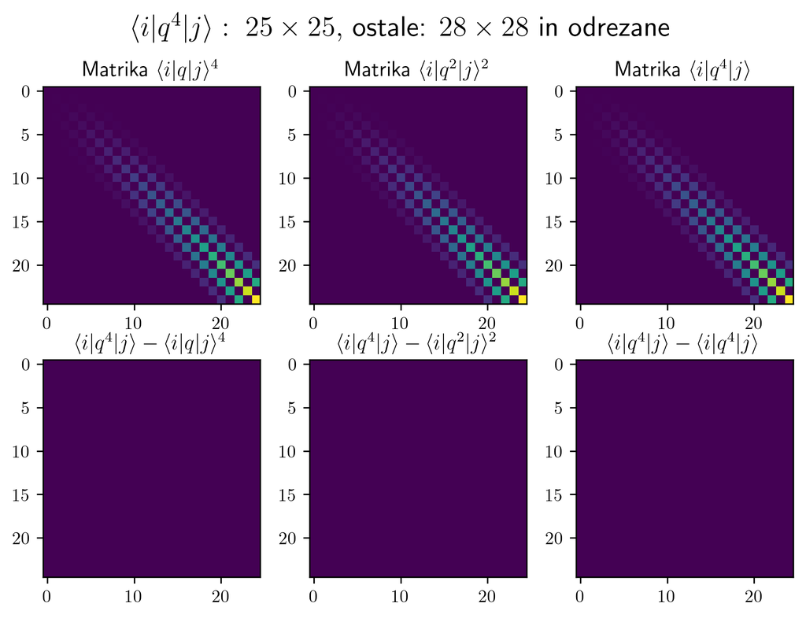

**Primerjava 2:** Če pri matričnem množenju uporabimo večje matrike (N=28) in jih nato odrežemo, rezultat konvergira k vrednostim $ \langle i | q^4 | j \rangle $.

## Numerična diagonalizacija matrik

Za reševanje matrične enačbe sedaj potrebujemo učinkovit postopek za diagonalizacijo matrik. V primerjavo bomo vzeli diagonalizacijo po Jacobijevi metodi v lastni implementaciji (Python/numpy in C++), numpy metodo `numpy.linalg.eig` in metodo `Eigen::SelfAdjointEigenSolver` iz paketa Eigen za C++.

Metode bomo testirali s pomočjo generiranih naključnih matrik velikosti $2\times2$ do $100 \times 100$. Primerjali bomo hitrost in natančnost diagonalizacije (s pomočjo kvadrata ne-diagonalne Frobeniusove norme $P_M = \lVert M \rVert_F^2 \; - \sum_{i=1}^{n} M_{ii}^2$).

#### Jacobijev algoritem

Za primerjavo z metodami v programskih paketih bomo "na roke" implementirali [Jacobijev algoritem za izračun lastnih vrednosti in lastnih vektorjev](https://en.wikipedia.org/wiki/Jacobi_eigenvalue_algorithm). To storimo tako v "enostavnem" programskem jeziku `Python` (z uporabo knjižnice `numpy`, saj je to najbolj realen praktičen primer) in v "hitrem" programskem jeziku `C++`.

Gre za iterativno metodo, ki jo lahko skiciramo v naslednjih korakih:

1. Imamo simetrično matriko $S$ in Givensovo rotacijsko matriko $G = G(i,j,\theta)$. Tedaj je $S' = G^\top S \; G$ simetrična in podobna $S$.
2. (Zaradi optimizacije) si izberemo po absolutni vrednosti največji člen $S_{ij}$, ki ga imenujemo $\tt{pivot}$. Sestavimo tako rotacijsko matriko $G$, da je $S'_{ij} = S'_{ji} = 0$. To ponovimo $N = n(n-1)/2$-krat ($n$ je velikost matrike in $N$ število ne-diagonalnih členov). Če na matriko apliciramo $N$ Givensovih/Jacobijevih rotacij, takšno skupinsko operacijo definiramo kot $\tt{sweep}$.
3. Ponovimo poljubno mnogo operacij $\tt{sweep}$, da dosežemo željeno numerično natančnost ($P$). Natančnost merimo kot $ P = \lVert S' \rVert_F^2 \; - \sum_{i=1}^{n} S_{ii}^2$.

Implementacijo testiramo in ugotovimo, da ustrezno diagonalizira matriko.

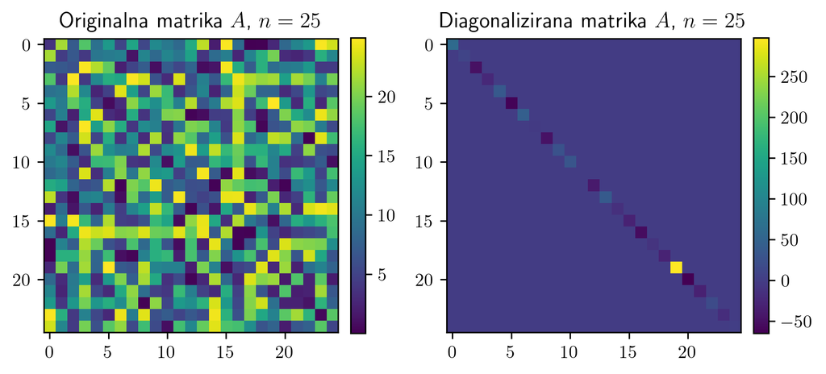

**Testna matrika $n=25$:** Testno matriko velikosti $N$ generiramo tako, da po diagonali nanesemo različne lastne vrednosti in nato simetrično po zgornji in spodnji trikotni dodamo naključna števila približno istega velikostnega razreda. Ne-diagonalna norma $P_A$ = 1.13e-08

Različne implementacije algoritmov za diagonalizacijo lahko sedaj primerjamo po hitrosti izvedbe za vsako peto matriko v naboru 100 matrik. Implementacijo v C++ smo v strojni jezik prevedli s komando in parametri `g++ -O3 -std=c++11 -I ./Eigen eigenDiag.cpp -o testEigen`.

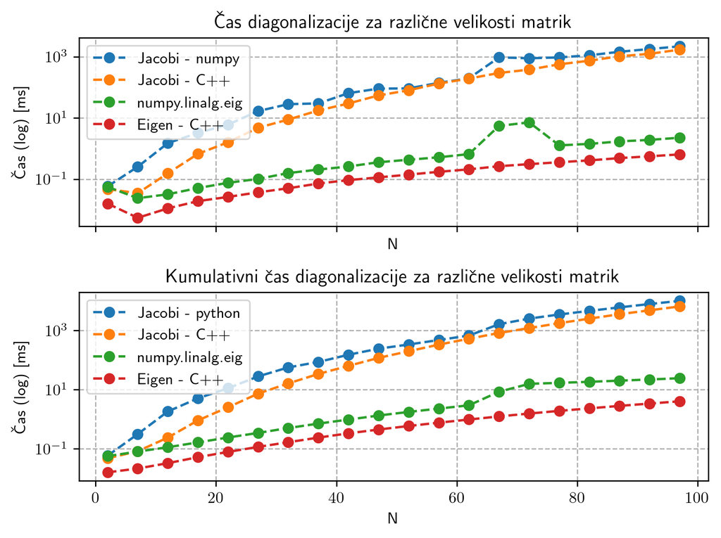

Iz grafa razberemo, da implementacija v jeziku `C++` ni bistveno hitrejša (pomnožena kvečjemu za neko konstanto) s povečevanjem velikosti matrik. Pri primerjavi hitrosti smo za Jacobijevo metodo targetirali $P$ sorazmeren z $N$, kar je privzeto obnašanje ostalih dveh implementacij iz programskih paketov.

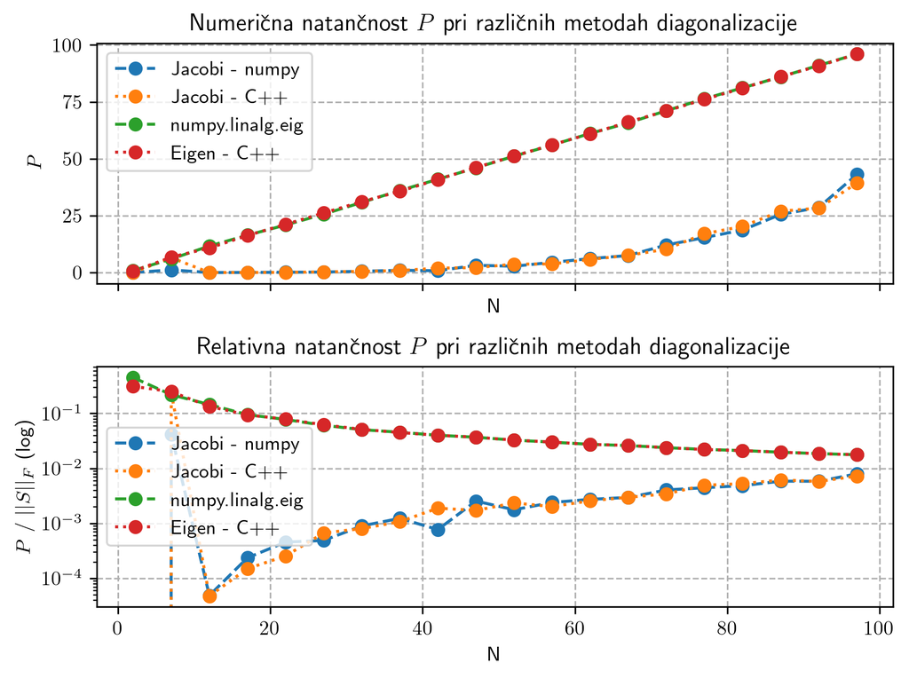

Zaradi učinkovitosti, preprostosti uporabe in dobre integracije s Pythonom se v nadaljevanju odločimo za uporabo funkcije `numpy.linalg.eig`.

## **An**harmonski oscilator

Sedaj z diagonalizacijo rešimo perturbiran Hamiltonjan za anharmonski oscilator. Zavedamo se, da ima Hamiltonjan dejansko neskončno lastnih funkcij/vektorjev $ | n \rangle $ in lastnih vrednosti $E_n$. Torej lahko v naši simulaciji obravnavam samo približek z (dovolj) velikim $n$.

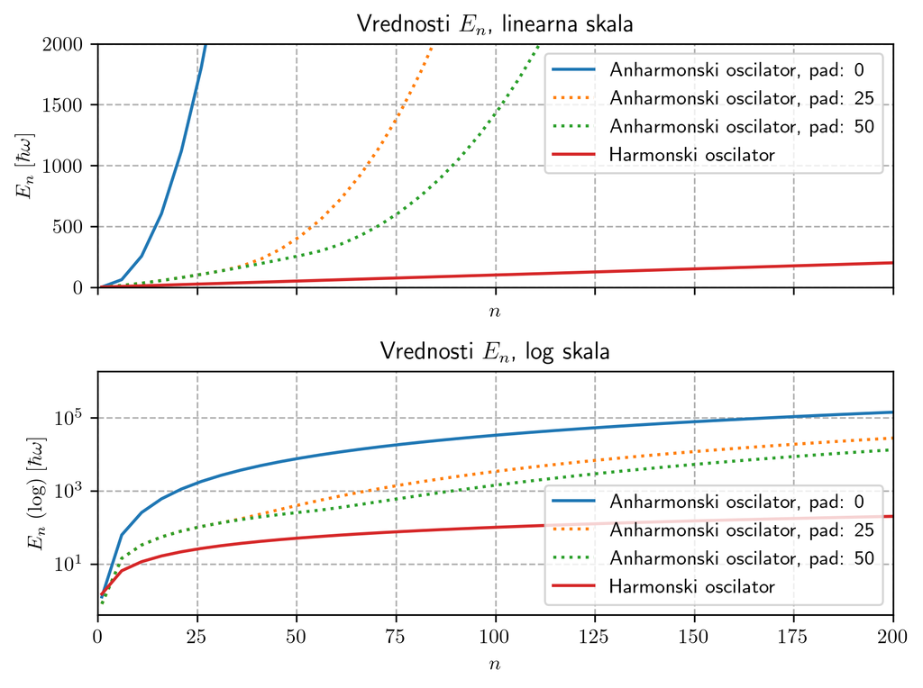

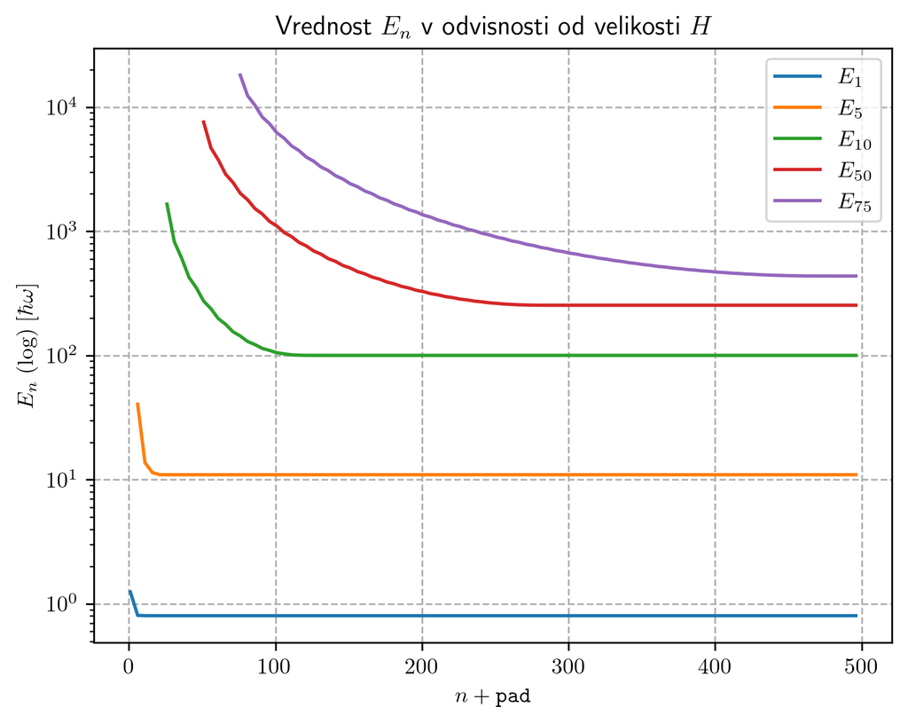

Ugotovimo, da se vrednost $E_n$ numerično sčasoma ustali. Torej lahko izrišemo energijske nivoje, če le vzamemo dovolj veliko vrednost $\tt{pad}$. Iz zgornjega grafa dobimo zelo grobo oceno $\texttt{pad} \approx 10 \cdot n $. Izrišimo še energijske nivoje:

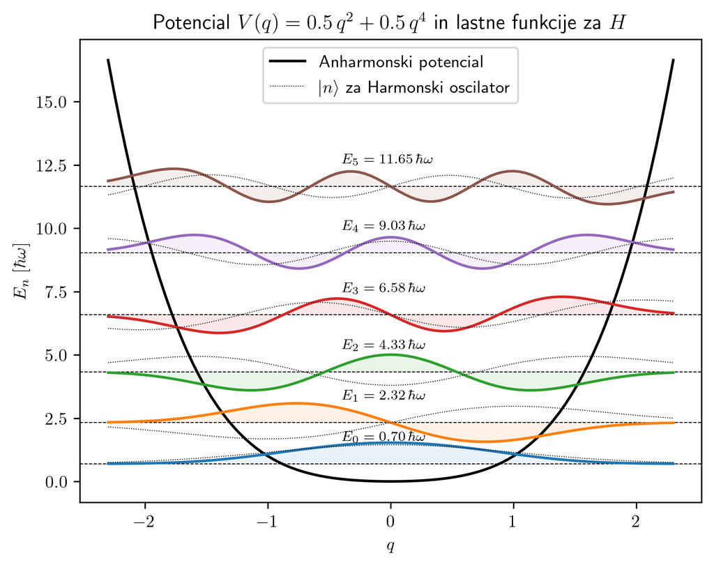

[video not shown]

**Animacija 1**: Anharmonski oscilator v limiti $\lambda \to 0$. Prikazujemo potencial (črna), vrednosti lastne energije (črtkane vodoravne), verjetnostno gostoto za lastne funckcije $H$ (barvne polne črte) in (referenčne) verjetnostno gostoto harmonskega oscilatorja (črtkano). Anharmonski oscilator limitira h harmonskemu.

## Dodatek: Oscilator z dvema minimumoma

Analizo ponovimo zdaj še z malo drugačnim hamiltonjanom $H_2 = {p^2\over 2} - 2q^2 + {q^4\over 10} \>$. Torej v potencialu z dvema minimumoma.

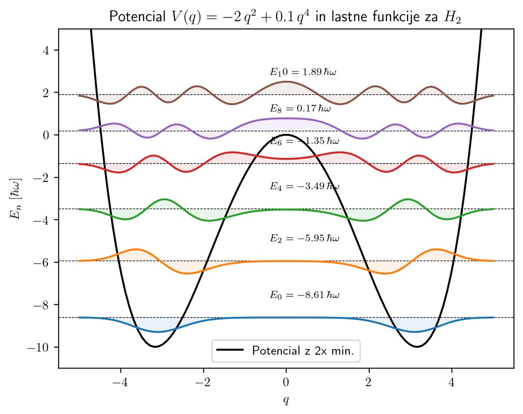

Opazimo, da je delec z nižjimi energijami lahko lokaliziran predvsem v minimumih potencialov (kvantno tuneliranje?). delec z višjo energijo pa lahko najdemo na celotni širini potenciala.

## Zaključek

Tekom analize smo s pomočjo kvantne perturbacijske teorije poiskali skupno matrično Hamiltonovo funkcijo za anharmonski potencial $\lambda q^4$ in potencial z dvema minimumoma. Testirali smo različne numerične načine za diagonalizacijo matrik tako v C++ kot v Pythonu. Z numerično diagonalizacijo smo rešili matrični sistem za anharmonski oscilator in oscilator z dvema minimumoma. Določili smo energijske nivoje ter lastne funkcije. Preverili smo korespondenčno načelo za limito $\lambda \to 0$ in ugotovili, da anharmonski oscilator v tej limiti (torej kot ugasne anharmonski) člen postane nazaj harmonski.

Luka Skeledžija, [Github source 🔗](https://github.com/lukaske/mafijski-praktikum/tree/main/MFPR/03_eigenstates), 2023